# Travel Time Matrix to Maps

## Notebook Purpose

1. Setting Up the Travel Time Matrix
2. Computing a Transit Accessibility Score
3. Computing Isochrones as Interprettable Scores
4. Wrangling Part II (NA Insertion)
5. Exporting the Data

## 0) Useful Libraries

```r
# import custom scoring, cleaning, and visualization functions
source('../0 - custom_functions/functions.R')

# wrangling/convenience
library(tidyverse)
library(glue)
library(stringr)
library(sf)
library(data.table)
library(bit64)

# visualization
library(leaflet)
library(mapview); mapviewOptions(platform = 'leafgl')

# For pretty knitting
library(lemon)
knit_print.data.frame <- lemon_print
knit_print.tbl <- lemon_print
knit_print.summary <- lemon_print

cleanpath <- "../../data/2_clean"
comppath <- "../../data/3_computed/"
```

## 1) Setting Up the Travel Time Matrix

### Import the travel time matrix

```r
# import travel time matrix
ttm <- read.table(gzfile(paste0(comppath, "main_travel_time_matrix--time_aggregated.csv.gz"),
                         "main_travel_time_matrix--time_aggregated.csv"), # file within zip
                  header=T, quote="\"", sep=",") # format into a table
# convert Ids to  factor
ttm$fromId <- as.factor(ttm$fromId)
ttm$toId <- as.factor(ttm$toId)

## Replace travel times less than 1 minute to 1 minute
# This is done to prevent infinity values in the scoring since
# 1 minute is still a reasonable time for trips in the 0 - 1 min range.
ttm$avg_time <- pmax(ttm$avg_time, 1)

# peek
head(ttm)
```

|  | fromId | toId | avg_time | sd_time |
| --- | --- | --- | --- | --- |
| 1 | 59150004004 | 10 | 99.76316 | 5.364721 |
| 2 | 59150004004 | 15 | 72.48718 | 3.401794 |
| 3 | 59150004004 | 157 | 96.69231 | 3.001349 |
| 4 | 59150004004 | 1759 | 106.82051 | 4.388213 |
| 5 | 59150004004 | 1760 | 46.58974 | 2.642944 |
| 6 | 59150004004 | 1822 | 76.64103 | 3.990035 |

### Import all dissemination block data

```r
# import dissemination blocks and keep id and pop columns
origins <- fread(file.path(cleanpath, "vancouver_db.csv"))[, .(id, pop, lat, lon)]

# replace commas in population column
origins$pop <- str_replace_all(origins$pop, ',', '')

# change col types
origins$pop <- as.numeric(origins$pop)
origins$id <- as.factor(origins$id)
n_origins <- nrow(origins)


paste('Origin Rows: ', n_origins)
```

```
[1] "Origin Rows:  15197"
```

```r
head(origins)
```

| id | pop | lat | lon |
| --- | --- | --- | --- |
| 59150004004 | 35 | 49.3739 | -123.2738 |
| 59150004005 | 50 | 49.3746 | -123.2757 |
| 59150004006 | 94 | 49.3738 | -123.2763 |
| 59150004011 | 0 | 49.3735 | -123.2725 |
| 59150004012 | 0 | 49.3725 | -123.2729 |
| 59150004013 | 0 | 49.3724 | -123.2728 |

### Import all amenity data

```r
# import amenities (Cultural/Art facilities)
destinations <- fread(file.path(cleanpath, "vancouver_facilities.csv"))

# see summary counts of each amenity
destinations %>% group_by(type) %>% summarise(count = n()) %>% arrange(desc(count))
```

| type | count |
| --- | --- |
| gallery | 99 |
| museum | 92 |
| library or archives | 89 |
| theatre/performance and concert hall | 76 |
| artist | 48 |
| heritage or historic site | 28 |
| art or cultural centre | 6 |
| miscellaneous | 6 |
| festival site | 2 |

```r
# filter types to keep only 4 most frequent amenities
target_amenities <- c('gallery',
                      'museum',
                      'library or archives',
                      'theatre/performance and concert hall')

destinations <- destinations %>% filter(type %in% target_amenities)

# keep only id and type columns
destinations <- destinations[ , .(id, type)]

# change column types
destinations$type <- as.factor(destinations$type)
destinations$id <- as.factor(destinations$id)

n_amenities <- nrow(destinations)
paste('Destinations: ', n_amenities)
```

```
[1] "Destinations:  356"
```

```r
head(destinations)
```

| id | type |
| --- | --- |
| 10 | museum |
| 15 | museum |
| 24 | museum |
| 115 | library or archives |
| 157 | gallery |
| 215 | library or archives |

### Import amenity weights:

```r
# import amenity weights
amenity_wts <- read.csv(paste0(cleanpath, '/amenity_weights/amenity_weights.csv'))

# id to type factor
amenity_wts$id <-  as.factor(amenity_wts$id)

head(amenity_wts)
```

|  | id | weight |
| --- | --- | --- |
| 1 | 2292 | 0.4715253 |
| 2 | 2692 | 0.6862229 |
| 3 | 4546 | 0.6713151 |
| 4 | 6749 | 0.5692166 |
| 5 | 7153 | 0.8031763 |
| 6 | 7806 | 0.5694037 |

```r
# Check that all the travel time matrix amenity IDs are in the weighted IDs set
# this NEEDS to be true for the join to work
check <- all(unique(ttm$toId) %in% unique(amenity_wts$id))
paste('Are all the ttm amenity IDs in the weighted IDs set? =', check)
```

```
[1] "Are all the ttm amenity IDs in the weighted IDs set? = TRUE"
```

### Fixed unequal number of ttm amenity IDs in the weighted IDs If check == False

```r
if (check == F) {

  # ttm ids that appear in the weights ids
  ttm_id_in_wts <- unique(ttm$toId)[unique(ttm$toId) %in% unique(amenity_wts$id)]

  # subset ids not in amenity wts
  ttm_id_not_in_wts <- unique(subset(ttm, !(toId %in% ttm_id_in_wts))$toId)
  ttm_id_not_in_wts <- as.data.frame(list("id_not_in_wts" = ttm_id_not_in_wts))

  paste('Number of id that not in amenity wts ', ttm_id_not_in_wts %>% nrow())

  # assign minimum weight on those places
  ttm_id_not_in_wts$weight <- min(amenity_wts$weight)
  colnames(ttm_id_not_in_wts)[1] <- "id"

  # add it to amenity weights
  amenity_wts <- rbind(amenity_wts, ttm_id_not_in_wts)

  # Check: are all the ttm amenity IDs in the weighted IDs set?
  check <- all(unique(ttm$toId) %in% unique(amenity_wts$id))
  paste('Are all the ttm amenity IDs in the weighted IDs set? (needs to be true for the join to work) =', check)
}
```

### Join ttm, destination types, and amenity weights

```r
if (check == TRUE){
  # join amenity weights to amenity types
  destinations <- left_join(destinations, amenity_wts, by = c('id' = 'id'))

  # join to ttm
  # use left join since we only care to keep existing amenities in the ttm
  ttm <-  left_join(ttm, destinations, by = c('toId' = 'id'))
}

head(ttm)
```

|  | fromId | toId | avg_time | sd_time | type | weight |
| --- | --- | --- | --- | --- | --- | --- |
| 1 | 59150004004 | 10 | 99.76316 | 5.364721 | museum | 0.4829706 |
| 2 | 59150004004 | 15 | 72.48718 | 3.401794 | museum | 0.2669118 |
| 3 | 59150004004 | 157 | 96.69231 | 3.001349 | gallery | 0.5354125 |
| 4 | 59150004004 | 1759 | 106.82051 | 4.388213 | museum | 0.3589059 |
| 5 | 59150004004 | 1760 | 46.58974 | 2.642944 | gallery | 0.4060835 |
| 6 | 59150004004 | 1822 | 76.64103 | 3.990035 | museum | 0.6582380 |

```r
# descriptive info: how many origins actually have transit accessibility
paste('Origins considered:', round((length(unique(ttm$fromId))/n_origins)*100, 2), '%')
```

```
[1] "Origins considered: 94.38 %"
```

```r
paste('Destinations considered:', round(length(unique(ttm$toId))/n_amenities*100, 2), '%')
```

```
[1] "Destinations considered: 96.91 %"
```

```r
paste('Rows = ', nrow(ttm))
```

```
[1] "Rows =  4172482"
```

## 2) Computing a Transit Accessibility Score

Notes:

- We don’t scale the data before score computation because we care about the scale of time and standard deviation. We should use their values as is, otherwise scaling will give them equal weighing again when this is a bad assumption.
- Log normalizing the score isn’t important as the score visualization depends on the quantiles taken from the distribution of scores. Since log only shifts values, the visualizations will be identical.

```r
score_list <- list()
score_list_weighted<-list()
i <- 1

for (n in 1:4) {

  # we want nearest 1,2,3, and ALL
  # so at n = 4 we reassign n as NULL
  if (n == 4) { n <- NULL }

  # unweighted score
  score <- sum_score_fxn(ttm, nearest_n = n, weight = FALSE, log_normalize_score = FALSE)

  # weighted score
  score_weighted <- sum_score_fxn(ttm, nearest_n = n, weight = TRUE, log_normalize_score = FALSE)

  # append
  score_list[[i]] <- score
  score_list_weighted[[i]]<-score_weighted
  i <- i+1

}

# bind the score frames together and sort them by DBUID
scores_long_unweighted <- rbindlist(score_list) %>% arrange(fromId, nearest_n)
scores_long_weighted <- rbindlist(score_list_weighted) %>% arrange(fromId, nearest_n)

# create a long data table with factors
scores_long <- rbindlist(list(scores_long_weighted, scores_long_unweighted))
```

## 3) Computing Isochrones as Interprettable Scores

```r
# only keep the nearest amenity for isochrone categorization
# this can also be changed to be an average of the nearest 2 or 3
isochrone_frame <- ttm %>%
  group_by(fromId, type) %>%
  summarise(avg_time = min(avg_time))

# isochrone frame
isochrone_frame$time_groups <-  with(isochrone_frame,
                                   ifelse(avg_time < 15, "15",
                                   ifelse(avg_time < 30, "30",
                                   ifelse(avg_time < 45, "45",
                                   ifelse(avg_time < 60, "60",
                                   ifelse(avg_time < 75, "75",
                                   ifelse(avg_time < 90, "90", "90+")))))))

isochrone_frame <- isochrone_frame[, c(1,2,4)]

head(isochrone_frame)
```

| fromId | type | time_groups |
| --- | --- | --- |
| 59150004004 | gallery | 45 |
| 59150004004 | library or archives | 45 |
| 59150004004 | museum | 45 |
| 59150004004 | theatre/performance and concert hall | 60 |
| 59150004005 | gallery | 45 |
| 59150004005 | library or archives | 45 |

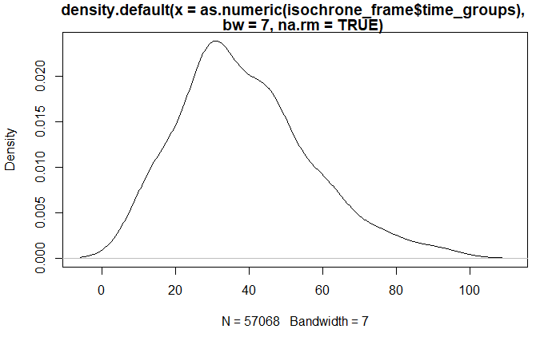

```r
# see isochrone times density
plot(density(as.numeric(isochrone_frame$time_groups), na.rm = TRUE, bw = 7))
```

## 4) Dataset Wrangling Part II (NA Insertion)

**Filling IDs with NA:**

Each origin (fromId) should have 32 different scores since there are:

- 2 weight options * 4 amenity options * 4 nearest options = 32

**Adding IDs that weren’t included:**

In addition to filling these missing values of the 32 expected values, there are also IDs that need to entirely be re-added since they may not have any transit and so wouldn’t be in the dataframe to begin with.

### Accessibility Scores Frame

```r
source('../0 - custom_functions/functions.R')

# values per ID = 4 * 4 * 2 = 32

# initial check
missing_scores <- check_rows(check_frame = scores_long,
                             origins_frame = origins,
                             rows_per_dissemination_block = 32,
                             frame_type = 'ACCESSIBILITY SCORES FRAME')
```

```
[1] "ACCESSIBILITY SCORES FRAME"

[1] "458256 of 458976 rows filled (99.84%)"
[1] "720 existing IDs to fill."

[1] "458256 of 485584 rows filled (94.37%)"
[1] "27328 IDs to add"
```

```r
# fill
all_scores_long <- NA_table_filler(scores_long,
                                   custom_idx = missing_scores,
                                   frame_type = 'score')

# post fill check
missing_scores <- check_rows(check_frame = all_scores_long,
                             origins_frame = origins,
                             rows_per_dissemination_block = 32,
                             frame_type = 'POST FILL CHECK: SCORES FRAME')
```

```
[1] "POST FILL CHECK: SCORES FRAME"

[1] "486304 of 486304 rows filled (100%)"
[1] "0 existing IDs to fill."

[1] "486304 of 486304 rows filled (100%)"
[1] "0 IDs to add"
```

### Isochrone Frame

```r
# values per ID = 4

# initial check
missing_times <- check_rows(check_frame = isochrone_frame,
                             origins_frame = origins,
                             rows_per_dissemination_block = 4,
                             frame_type = 'ISOCHRONE FRAME')
```

```
[1] "ISOCHRONE FRAME"

[1] "57282 of 57372 rows filled (99.84%)"
[1] "90 existing IDs to fill."

[1] "57282 of 60698 rows filled (94.37%)"
[1] "3416 IDs to add"
```

```r
# fill
all_isochrone_frame <- NA_table_filler(isochrone_frame,
                                   custom_idx = missing_times,
                                   frame_type = 'isochrone')

# post fill check
missing_times <- check_rows(check_frame = all_isochrone_frame,
                             origins_frame = origins,
                             rows_per_dissemination_block = 4,
                             frame_type = 'ISOCHRONE FRAME')
```

```
[1] "ISOCHRONE FRAME"

[1] "60788 of 60788 rows filled (100%)"
[1] "0 existing IDs to fill."

[1] "60788 of 60788 rows filled (100%)"
[1] "0 IDs to add"
```

**Final step!**

```r
# right join with origins to include origins without transit access

all_scores_long_pop <- left_join(all_scores_long,
                                 origins[, c('id', 'pop')], # pop col only
                                 by = c('fromId' = 'id'))

all_isochrone_frame_pop <- left_join(all_isochrone_frame,
                                     origins[, c('id', 'pop')], # pop col only
                                     by = c('fromId' = 'id'))

head(all_scores_long_pop)
```

| fromId | type | score | weight | nearest_n | pop |
| --- | --- | --- | --- | --- | --- |
| 59150004004 | gallery | 0.06026519 | yes | 1 | 35 |
| 59150004004 | gallery | 0.05837009 | no | 1 | 35 |
| 59150004004 | gallery | 0.07036125 | yes | 2 | 35 |
| 59150004004 | gallery | 0.07054259 | no | 2 | 35 |
| 59150004004 | gallery | 0.08046465 | yes | 3 | 35 |
| 59150004004 | gallery | 0.08078048 | no | 3 | 35 |

```r
head(all_isochrone_frame_pop)
```

| fromId | type | time_groups | pop |
| --- | --- | --- | --- |
| 59150004004 | gallery | 45 | 35 |
| 59150004004 | library or archives | 45 | 35 |
| 59150004004 | museum | 45 | 35 |
| 59150004004 | theatre/performance and concert hall | 60 | 35 |
| 59150004005 | gallery | 45 | 50 |
| 59150004005 | library or archives | 45 | 50 |

```r
# check to make sure all rows are there!!!
expected_rows_score <- nrow(origins)*32
expected_rows_isoch <- nrow(origins)*4

paste('Scores Check: ', nrow(all_scores_long_pop) == expected_rows_score)
```

```
[1] "Scores Check:  TRUE"
```

```r
paste('Isochrone Check: ', nrow(all_isochrone_frame_pop) == expected_rows_isoch)
```

```
[1] "Isochrone Check:  TRUE"
```

## 5) Exporting the Accessibility Measures

```r
## Export checkpoint
write.csv(all_scores_long_pop,
          paste0(comppath, '/accessibility_measures/scores_frame.csv'),
          row.names = FALSE)

write.csv(all_isochrone_frame_pop,
          paste0(comppath, '/accessibility_measures/isochrone_frame.csv'),
          row.names = FALSE)
```